# LIS 490 HomeWork3

Kefu Zhu, kefuzhu2

Wednesday, September 22, 2016

HW 4 Due Tuesday Sept 27, 2016. Upload R file to Moodle with name: HW2_490IDS_YOUR_CLASSID.R

Notice we are using the new system with your unique class ID. You should have received an email with your unique class ID. Please make sure that ID is the only information on your hw that identifies you.

Do not remove any of the comments. These are marked by #

# Part 1: Linear Regression Concepts

These questions do not require coding but will explore some important concepts from lecture 5.

“Regression” refers to the simple linear regression equation: y = B0 + B1*x

This homework will not discuss any multivariate regression.

## 1. (1 pt)

What is the interpretation of the coefficient B1? (What meaning does it represent?)

Your answer

**Answer**: The value of y is expected to increase by B1 units if the value of x is increased by 1 unit.

## 2. (1 pt)

If the residual sum of squares (RSS) of my regression is exactly 0, what does that mean about my model?

Your answer

**Answer**: All data points are exactly on the linear regression model. In other words, the model explained 100% of the data.

## 3. (2 pt)

Outliers are problems for many statistical methods, but are particularly problematic for linear regression. Why is that? It may help to define what outlier means in this case. (Hint: Think of how residuals are calculated)

Your answer

**Answer**: Because the model is fitted based on least sum of squares criterion, which is calculated by summing all squares of residuals, so if an outlier exists, it will have large value of residual, and it is especially influential for the model since the value of residual square is used to determine the coefficients.

# Part 2: Sampling and Point Estimation

The following problems will use the ggplot2movies data set and explore the average movie length of films in the year 2000.

Load the data by running the following code

```r
library(ggplot2movies)
data(movies)
```

## 4. (2 pts)

Subset the data frame to ONLY include movies released in 2000.

```r
movies <- subset(movies, movies$year == 2000)
```

Use the sample function to generate a vector of 1s and 2s that is the same length as the subsetted data frame. Use this vector to split the ‘length’ variable into two vectors, length1 and length2.

IMPORTANT: Make sure to run the following seed function before you run your sample function. Run them back to back each time you want to run the sample function.

Check: If you did this properly, you will have 1035 elements in length1 and 1013 elements in length2.

```r
set.seed(1848)
```

sample(…)

```r
# Store the sample result into a temporary vector
tmp <- sample(c(1,2),size = length(movies[, 1]), replace = TRUE)
# Split the 'length' variable based on values in the temporary vector
length1 <- movies$length[tmp==1]
length2 <- movies$length[tmp==2]
```

## 5. (3 pts)

Calculate the mean and the standard deviation for each of the two vectors, length1 and length2. Use this information to create a 95% confidence interval for your sample means. Compare the confidence intervals – do they seem to agree or disagree?

Your answer here

```r
mean_1 <- mean(length1)
mean_2 <- mean(length2)
SD_1 <- sd(length1)
SD_2 <- sd(length2)
confidence_interval_1 <- c(mean_1 - 1.96 * SD_1, mean_1 + 1.96 * SD_1)
confidence_interval_2 <- c(mean_2 - 1.96 * SD_2, mean_2 + 1.96 * SD_2)
```

```r
mean_1
```

```
## [1] 78.33623
```

```r
mean_2
```

```
## [1] 80.02073
```

```r
confidence_interval_1
```

```
## [1]  -0.2068226 156.8792864
```

```r
confidence_interval_2
```

```
## [1]   2.950393 157.091068
```

**Answer**: Since both intervals contain the the two sample means and the ranges of both intervals do not have a big difference, these two confidence intervals seem to agree.

## 6. (4 pts)

Draw 100 observations from a standard normal distribution. Calculate the sample mean. Repeat this 100 times, storing each sample mean in a vector called mean_dist. Plot a histogram of mean_dist to display the sampling distribution. How closely does your histogram resemble the standard normal? Explain why it does or does not.

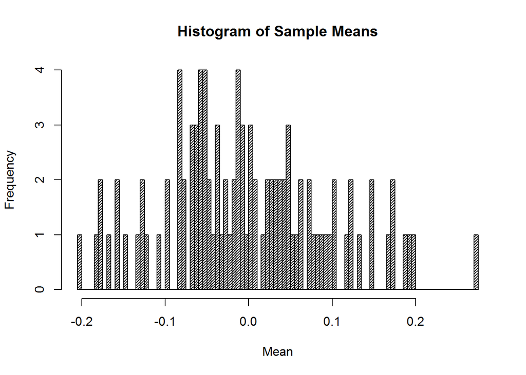

```r
mean_dist <- c()
for (i in 1:100) {
mean_dist[i] <- mean(rnorm(100, mean = 0, sd = 1))
}
hist(
mean_dist,
breaks = 100,
density = 40,
main = 'Histogram of Sample Means',
xlab = 'Mean'
)
```

## 7. (3 pts)

Write a function that implements Q6.

Your answer here

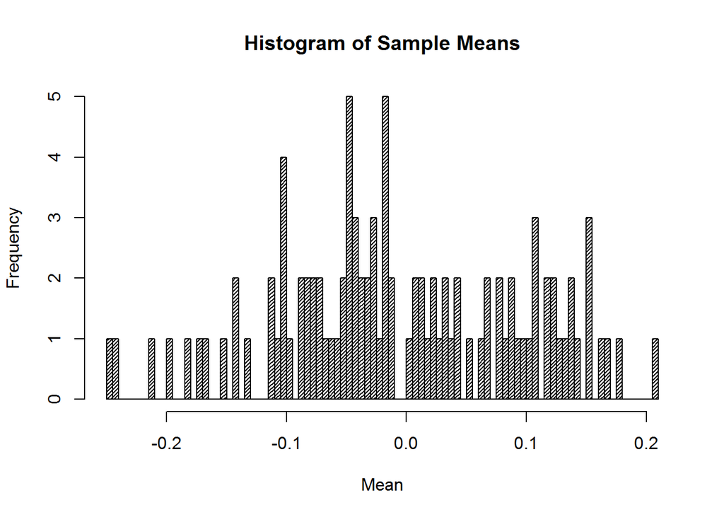

```r
HW.Bootstrap=function(distn,n,reps){
  set.seed(1848)

  #more lines here
  if(is.function(distn)!=TRUE) stop('Please provide a valid function')
  else if(is.numeric(n) & is.numeric(reps) == FALSE) stop('Please provide a number for randomization')
  else if(n < 0) stop ('Please provide a positive number of observations')
  else if(reps <0) stop ('Please provide a positvie number of repeats')
  else{
    mean_dist <- c()
    for (i in 1:reps) {
      mean_dist[i] <- mean(distn(n, mean = 0, sd = 1))
    }
    hist(mean_dist, breaks = reps, density = 40, main = 'Histogram of Sample Means', xlab = 'Mean')
  }
}

# Show case
HW.Bootstrap(rnorm,100,100)
```

# Part 3: Linear Regression

This problem will use the Boston Housing data set. Before starting this problem, we will declare a null hypthosesis that the crime rate has no effect on the housing value for Boston suburbs.

That is:

```
     H0: B1 = 0

     HA: B1 =/= 0
```

We will attempt to reject this hypothesis by using a linear regression

Load the data

```r
housing <- read.table(url("https://archive.ics.uci.edu/ml/machine-learning-databases/housing/housing.data"),sep="")
names(housing) <- c("CRIM","ZN","INDUS","CHAS","NOX","RM","AGE","DIS","RAD","TAX","PTRATIO","B","LSTAT","MEDV")
```

## 7. (2 pt)

Fit a linear regression using the housing data using CRIM (crime rate) to predict MEDV (median home value). Examine the model diagnostics using plot(). Would you consider this a good model or not? Explain.

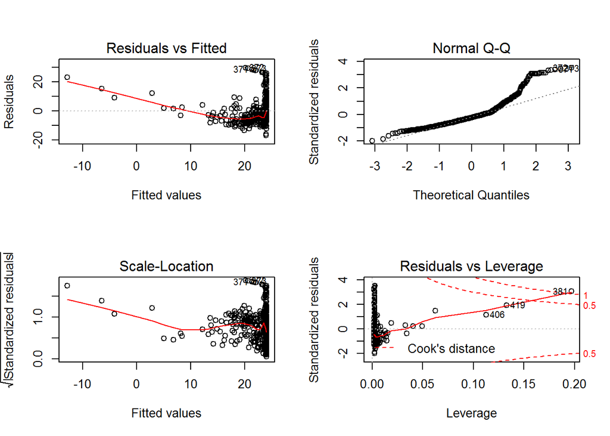

```r
attach(housing)
fit <- lm(MEDV~CRIM)
par(mfrow = c(2,2))
plot(fit)
```

**Answer**: Based on the dignostic plots, the data does not seem to be normally distributed and it also has problem of heteroscedasticity. Furthermore, the data also contains an outlier. So this is not a good model.

## 8. (2 pts)

Using the information from summary() on your model, create a 95% confidence interval for the CRIM coefficient

```r
c(
  summary(fit)$coefficients[, 1]['CRIM'] - 1.96 * summary(fit)$coefficients[, 2]['CRIM'],
  summary(fit)$coefficients[, 1]['CRIM'] + 1.96 * summary(fit)$coefficients[, 2]['CRIM']
  )
```

```
##       CRIM       CRIM
## -0.5012154 -0.3291651
```

## 9. (2 pts)

Based on the result from question 8, would you reject the null hypothesis or not? (Assume a significance level of 0.05). Explain.

Your answer

**Answer**: Yes. I will reject the null hypothesis because zero is not in the 95% confidence interval of CRIM coefficient.

## 10. (1 pt)

Pretend that the null hypothesis is true. Based on your decision in the previous question, would you be committing a decision error? If so, which one?

Your answer

**Answer**: I will make a Type I Error

## 11. (1 pt)

Use the variable definitions from this site: https://archive.ics.uci.edu/ml/machine-learning-databases/housing/housing.names

Discuss what your regression results mean in the context of the data (using appropriate units) (Hint: Think back to Question 1)

## 12. (2 pt)

Describe the LifeCycle of Data for Part 3 of this homework.

**Answer**: The data is first obtained from UCI machine learning database, then the informative names are assigned to variables in the original dataset. Finally, the data is used for linear regression analysis which involes checking assumptions and interpreting results.